# Modeling and prediction for movies

## Setup

### Load packages

```r
setwd("~/coursera/statistics/linear-regression-model/project")
library(ggplot2)
library(dplyr)
library(statsr)

#for table output
library(pander)

#for summary variables
library(GGally)
```

### Load data

```r
load("movies.Rdata")
```

## Part 1: Data

Even though random sampling was used to create the sample, the origin of the data (rotten tomatoes and IMDB) has the responder bias, as the data is provided by volunteers. So we can’t generalize the conclusions for all population, only to the US population.

As random assignment was not used causality cannot be inferred.

## Part 2: Research question

Does a film made by Oscar winners, improves film rating ?

If the data provides evidence that hiring a team of Oscar winners improves film rating, the studio could redirect their hiring efforts to contract only these professionals, to build better and profitable films.

## Part 3: Exploratory data analysis

### The response variable

As the dataset provide two source of scores, is more pratical to unify theses scores.

The IMDB scores has the range 0..10 and the Rotten Tomatos the range 0..100.

As the follow summaries show, both scores are similar.

```r
summary(movies$imdb_rating) %>% pander()
```

| Min. | 1st Qu. | Median | Mean | 3rd Qu. | Max. |
| --- | --- | --- | --- | --- | --- |
| 1.9 | 5.9 | 6.6 | 6.493 | 7.3 | 9 |

```r
summary(movies$audience_score) %>% pander()
```

| Min. | 1st Qu. | Median | Mean | 3rd Qu. | Max. |
| --- | --- | --- | --- | --- | --- |
| 11 | 46 | 65 | 62.36 | 80 | 97 |

```r
summary(movies$critics_score) %>% pander()
```

| Min. | 1st Qu. | Median | Mean | 3rd Qu. | Max. |
| --- | --- | --- | --- | --- | --- |
| 1 | 33 | 61 | 57.69 | 83 | 100 |

Let’s create our new score:

```r
movies$overall_score <-  (((movies$imdb_rating * 10) + movies$audience_score + movies$critics_score) / 3)

summary(movies$overall_score) %>% pander()
```

| Min. | 1st Qu. | Median | Mean | 3rd Qu. | Max. |
| --- | --- | --- | --- | --- | --- |
| 12.67 | 48.33 | 62.67 | 61.66 | 77.67 | 94.67 |

### Summarize the Oscar features

```r
movies$has_oscar <- as.factor(movies$best_actor_win == "yes" | movies$best_actress_win == "yes" | movies$best_dir_win == "yes" | movies$best_pic_win == "yes")
```

### Summarize years between movie release and DVD release

```r
movies$time_releases <- movies$dvd_rel_year - movies$thtr_rel_year
```

### The research question

To verify if our research question has data, let’s use the inference command.

```r
inference(y = overall_score, x = has_oscar, data = movies, type = "ht", statistic = "mean", success = TRUE, method = "theoretical", alternative = "greater")
```

```
## Response variable: numerical
## Explanatory variable: categorical (2 levels)
## n_FALSE = 480, y_bar_FALSE = 60.8951, s_FALSE = 18.6535
## n_TRUE = 171, y_bar_TRUE = 63.809, s_TRUE = 16.88
## H0: mu_FALSE =  mu_TRUE
## HA: mu_FALSE > mu_TRUE
## t = -1.8843, df = 170
## p_value = 0.9694
```

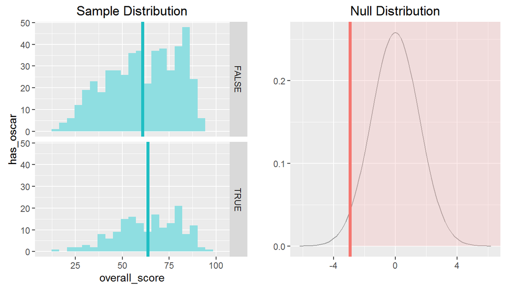

As p-value is larger we fail to reject the null hypothesis. So we can assume that a film win or not a Oscar does not make difference in this score.

### Possible variables

In this dataset there are many variables that aren’t useful to us, so we select the follow variables to work:

```r
#save the old version
movies_old <- movies
```

```r
movies$title <- NULL
```

```r
movies$studio <- NULL
```

Removed `imdb_rating`, `imdb_num_votes`, `critics_rating`, `critics_score`, `audience_rating` and `audience_score` variables because we built our `overall_score` variable that unifies all these.

```r
movies$imdb_rating <- NULL
movies$imdb_num_votes <- NULL
movies$critics_rating <- NULL
movies$critics_score <- NULL
movies$audience_rating <- NULL
movies$audience_score <- NULL
```

Removed `actor1`, `actor2`, `actor3`, `actor4`, `actor5` because these variables are used to build the `*_win` variables, so there is a high correlation between these variables.

```r
movies$actor1 <- NULL
movies$actor2 <- NULL
movies$actor3 <- NULL
movies$actor4 <- NULL
movies$actor5 <- NULL
```

Removed `best_actor_win`, `best_actress_win`, `best_dir_win`, `best_pic_win` because these variables are used to build the `has_oscar` variables, so there is a high correlation between these variables.

```r
movies$best_actor_win <- NULL
movies$best_actress_win  <- NULL
movies$best_dir_win  <- NULL
movies$best_pic_win  <- NULL
```

Remove this two informational variables.

```r
movies$imdb_url <- NULL
movies$rt_url <- NULL
```

Removed `dvd_rel_year`, `dvd_rel_day`, `dvd_rel_month`, `thtr_rel_year`, `thtr_rel_day`, `thtr_rel_month` because these variables are used to build the `time_releases` variables, so there is a high correlation between these variables.

```r
movies$dvd_rel_year <- NULL
movies$thtr_rel_year <- NULL

movies$dvd_rel_day <- NULL
movies$thtr_rel_day <- NULL

movies$dvd_rel_month <- NULL
movies$thtr_rel_month <- NULL
```

Remaining variables.

```r
names(movies) %>%
  as.data.frame() %>%
  data.table::setnames(., c("variable")) %>%
  pander()
```

| variable |
| --- |
| title_type |
| genre |
| runtime |
| mpaa_rating |
| best_pic_nom |
| top200_box |
| director |
| overall_score |
| has_oscar |
| time_releases |

Next we replace NA in numeric variables by zero:

```r
movies$time_releases <- ifelse(is.na(movies$time_releases), 0, movies$time_releases)
movies$runtime <- ifelse(is.na(movies$runtime), 0, movies$runtime)
movies$director <- ifelse(is.na(movies$director), "Unknow", movies$director)
```

Let’s plot the correlations plots for variables with low cardinality (otherwise we couldn’t see anything).

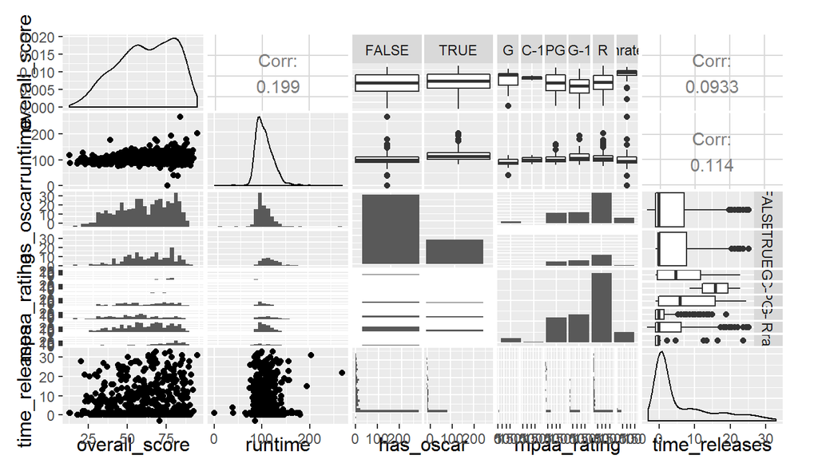

```r
ggpairs(movies, columns = c("overall_score", "runtime", "has_oscar", "mpaa_rating", "time_releases"))
```

## Part 4: Modeling

Let’s start with a Full model, and proceding removing the lesse significant p-value predictor.

This method allow us to build a model with the most statistically significant variables.

```r
movies_model <- lm(data = movies, formula = overall_score ~ title_type + genre + runtime + mpaa_rating + best_pic_nom + top200_box + director + has_oscar + time_releases)
```

### Check conditions for the model

#### Linear relationship

##### `runtime` variable

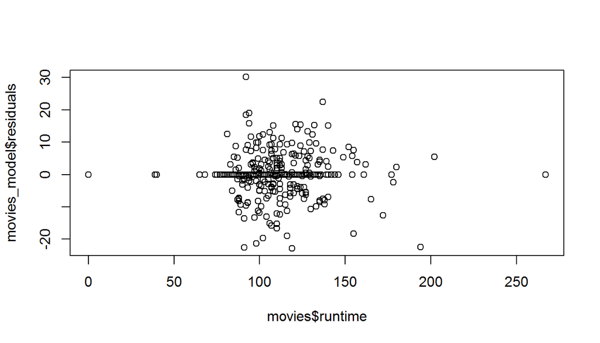

```r
plot(movies_model$residuals ~ movies$runtime)
```

The residual plot dows not shows a random scatter around zero, so there is no linear relationship.

##### `time_releases` variable

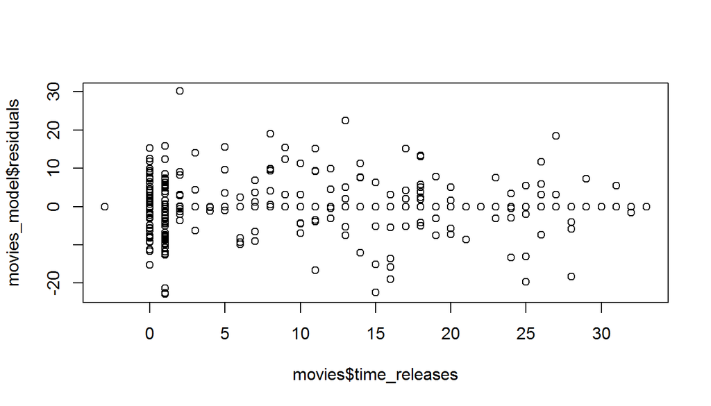

```r
plot(movies_model$residuals ~ movies$time_releases)
```

The residual plot shows a random scatter around zero, so there is a linear relationship.

#### Near normal residuals with mean zero

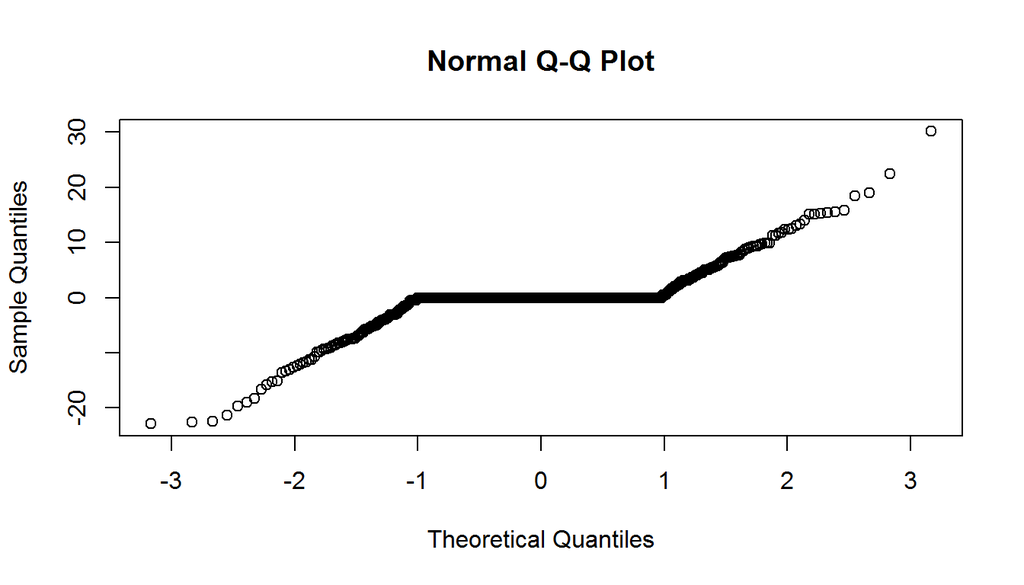

```r
qqnorm(movies_model$residuals)
```

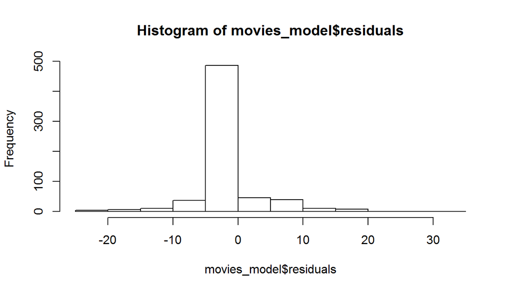

```r
hist(movies_model$residuals)
```

There a high concentration around zero, but this is not a nearly normal distribution.

#### Constant Variability of Residuals

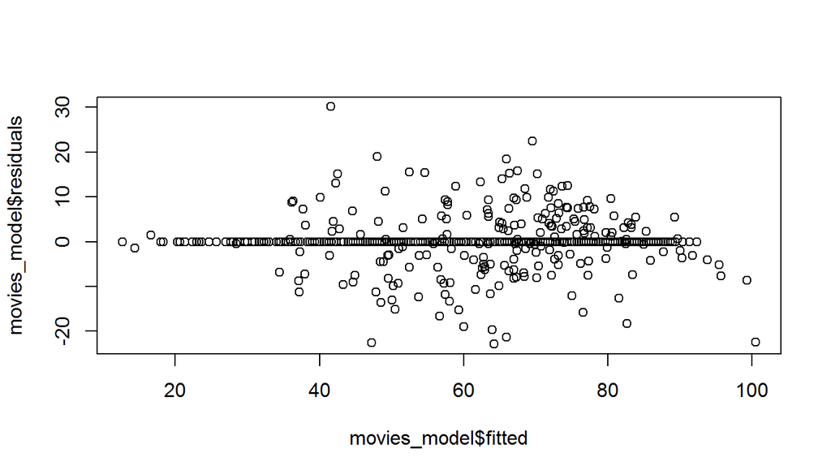

```r
plot(movies_model$residuals ~ movies_model$fitted)
```

There is no random scatter.

Let’s remove `runtime` due to the lack of linear relationship, and try again.

```r
movies_model <- lm(data = movies, formula = overall_score ~ title_type + genre + mpaa_rating + best_pic_nom + top200_box + director + has_oscar + time_releases)
```

### Check conditions for the model

#### Linear relationship

##### `time_releases` variable

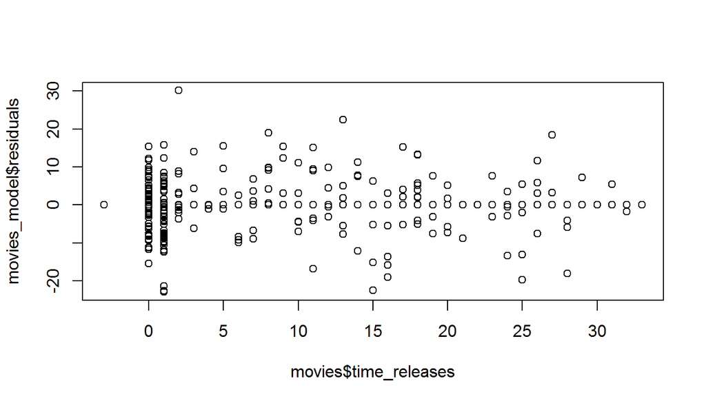

```r
plot(movies_model$residuals ~ movies$time_releases)
```

The residual plot shows a random scatter around zero, so there is a linear relationship.

#### Near normal residuals with mean zero

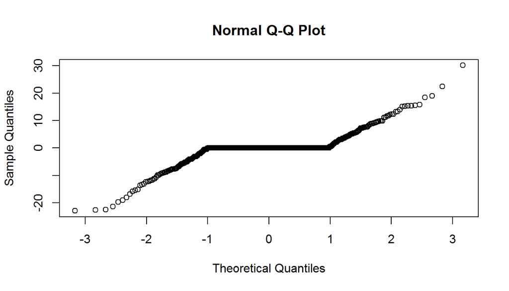

```r
qqnorm(movies_model$residuals)
```

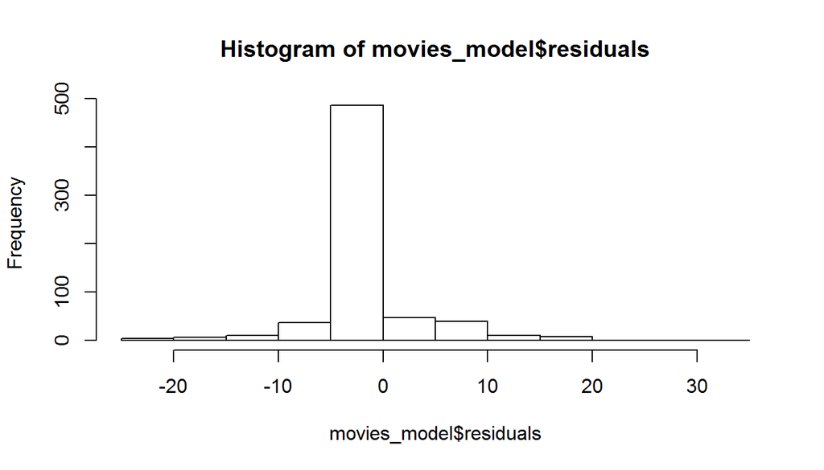

```r
hist(movies_model$residuals)
```

There a high concentration around zero, but this is not a nearly normal distribution.

#### Constant Variability of Residuals

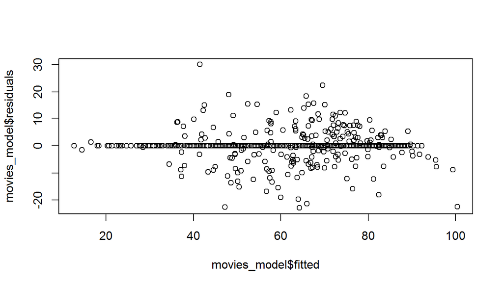

```r
plot(movies_model$residuals ~ movies_model$fitted)
```

### Stepwise Model Selection

We will use backwards elimination to try to find a better model with Adjusted R^2 criteria.

#### Step 1

```r
models <- data.frame(model = NULL, adjRsqtr = NULL, nr_try = NULL)
i <- 1
#1 Full
movies_model <- lm(data = movies, formula = overall_score ~ title_type + genre + mpaa_rating + best_pic_nom + top200_box + director + has_oscar + time_releases)
s <- summary(movies_model)
models <- rbind(models, data.frame(model = (as.character(s$call)[2]), adjRsqtr = s$adj.r.squared, nr_try = i))
i <- i + 1

#2 w/o genre
movies_model <- lm(data = movies, formula = overall_score ~ title_type + mpaa_rating + best_pic_nom + top200_box + director + has_oscar + time_releases)
s <- summary(movies_model)
models <- rbind(models, data.frame(model = (as.character(s$call)[2]), adjRsqtr = s$adj.r.squared, nr_try = i))
i <- i + 1

#3 w/o mpaa_rating
movies_model <- lm(data = movies, formula = overall_score ~ title_type + genre + best_pic_nom + top200_box + director + has_oscar + time_releases)
s <- summary(movies_model)
models <- rbind(models, data.frame(model = (as.character(s$call)[2]), adjRsqtr = s$adj.r.squared, nr_try = i))
i <- i + 1

#4 w/o best_pic_nom
movies_model <- lm(data = movies, formula = overall_score ~ title_type + genre + mpaa_rating + top200_box + director + has_oscar + time_releases)
s <- summary(movies_model)
models <- rbind(models, data.frame(model = (as.character(s$call)[2]), adjRsqtr = s$adj.r.squared, nr_try = i))
i <- i + 1

#5 w/o top200_box
movies_model <- lm(data = movies, formula = overall_score ~ title_type + genre + mpaa_rating + best_pic_nom + director + has_oscar + time_releases)
s <- summary(movies_model)
models <- rbind(models, data.frame(model = (as.character(s$call)[2]), adjRsqtr = s$adj.r.squared, nr_try = i))
i <- i + 1

#6 w/o director
movies_model <- lm(data = movies, formula = overall_score ~ title_type + genre + mpaa_rating + best_pic_nom + top200_box + has_oscar + time_releases)
s <- summary(movies_model)
models <- rbind(models, data.frame(model = (as.character(s$call)[2]), adjRsqtr = s$adj.r.squared, nr_try = i))
i <- i + 1

#7 w/o has_oscar
movies_model <- lm(data = movies, formula = overall_score ~ title_type + genre + mpaa_rating + best_pic_nom + top200_box + director  + time_releases)
s <- summary(movies_model)
models <- rbind(models, data.frame(model = (as.character(s$call)[2]), adjRsqtr = s$adj.r.squared, nr_try = i))
i <- i + 1

#8 w/o time_releases
movies_model <- lm(data = movies, formula = overall_score ~ title_type + genre + mpaa_rating + best_pic_nom + top200_box + director + has_oscar)
s <- summary(movies_model)
models <- rbind(models, data.frame(model = (as.character(s$call)[2]), adjRsqtr = s$adj.r.squared, nr_try = i))
i <- i + 1

models %>%
  arrange(desc(adjRsqtr)) %>%
  head(n = 1) %>%
  pander()
```

| model | adjRsqtr | nr_try |
| --- | --- | --- |
| overall_score ~ title_type + mpaa_rating + best_pic_nom + top200_box + director + has_oscar + time_releases | 0.5249 | 2 |

#### Step 2

```r
models <- data.frame(model = NULL, adjRsqtr = NULL, nr_try = NULL)
i <- 1

#1 Full
movies_model <- lm(data = movies, formula = overall_score ~ title_type + mpaa_rating + best_pic_nom + top200_box + director + has_oscar + time_releases)
s <- summary(movies_model)
models <- rbind(models, data.frame(model = (as.character(s$call)[2]), adjRsqtr = s$adj.r.squared, nr_try = i))
i <- i + 1

#1 w/o title_type
movies_model <- lm(data = movies, formula = overall_score ~ mpaa_rating + best_pic_nom + top200_box + director + has_oscar + time_releases)
s <- summary(movies_model)
models <- rbind(models, data.frame(model = (as.character(s$call)[2]), adjRsqtr = s$adj.r.squared, nr_try = i))
i <- i + 1

#3 w/o mpaa_rating
movies_model <- lm(data = movies, formula = overall_score ~ title_type + best_pic_nom + top200_box + director + has_oscar + time_releases)
s <- summary(movies_model)
models <- rbind(models, data.frame(model = (as.character(s$call)[2]), adjRsqtr = s$adj.r.squared, nr_try = i))
i <- i + 1

#4 w/o best_pic_nom
movies_model <- lm(data = movies, formula = overall_score ~ title_type + mpaa_rating + top200_box + director + has_oscar + time_releases)
s <- summary(movies_model)
models <- rbind(models, data.frame(model = (as.character(s$call)[2]), adjRsqtr = s$adj.r.squared, nr_try = i))
i <- i + 1

#5 w/o top200_box
movies_model <- lm(data = movies, formula = overall_score ~ title_type + mpaa_rating + best_pic_nom + director + has_oscar + time_releases)
s <- summary(movies_model)
models <- rbind(models, data.frame(model = (as.character(s$call)[2]), adjRsqtr = s$adj.r.squared, nr_try = i))
i <- i + 1

#6 w/o director
movies_model <- lm(data = movies, formula = overall_score ~ title_type + mpaa_rating + best_pic_nom + top200_box + has_oscar + time_releases)
s <- summary(movies_model)
models <- rbind(models, data.frame(model = (as.character(s$call)[2]), adjRsqtr = s$adj.r.squared, nr_try = i))
i <- i + 1

#7 w/o has_oscar
movies_model <- lm(data = movies, formula = overall_score ~ title_type + mpaa_rating + best_pic_nom + top200_box + director + time_releases)
s <- summary(movies_model)
models <- rbind(models, data.frame(model = (as.character(s$call)[2]), adjRsqtr = s$adj.r.squared, nr_try = i))
i <- i + 1

#8 w/o time_releases
movies_model <- lm(data = movies, formula = overall_score ~ title_type + mpaa_rating + best_pic_nom + top200_box + director + has_oscar)
s <- summary(movies_model)
models <- rbind(models, data.frame(model = (as.character(s$call)[2]), adjRsqtr = s$adj.r.squared, nr_try = i))
i <- i + 1

models %>%
  arrange(desc(adjRsqtr)) %>%
  head(n = 1) %>%
  pander()
```

| model | adjRsqtr | nr_try |
| --- | --- | --- |
| overall_score ~ title_type + mpaa_rating + best_pic_nom + top200_box + director + has_oscar + time_releases | 0.5249 | 1 |

#### Final Model

```r
movies_model <- lm(data = movies, formula = overall_score ~ title_type + mpaa_rating + best_pic_nom + top200_box + director + has_oscar + time_releases)
s <- summary(movies_model)
```

##### Check conditions for the model

###### Linear relationship

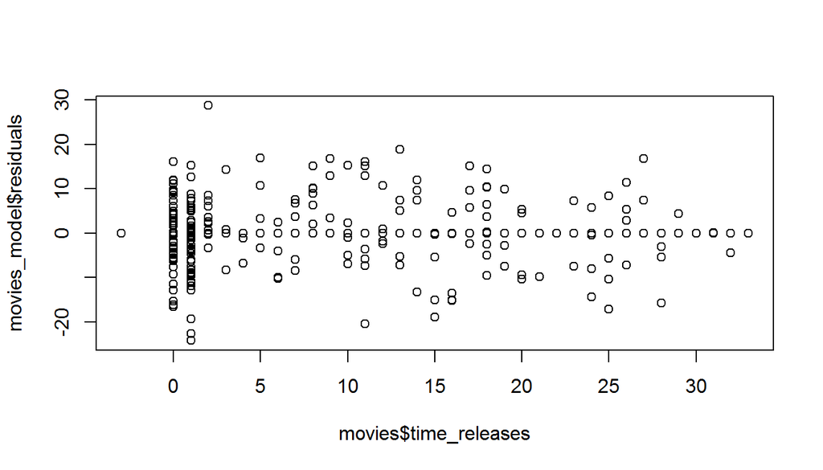

```r
plot(movies_model$residuals ~ movies$time_releases)
```

The residual plot shows a random scatter around zero, so there is a linear relationship.

###### Near normal residuals with mean zero

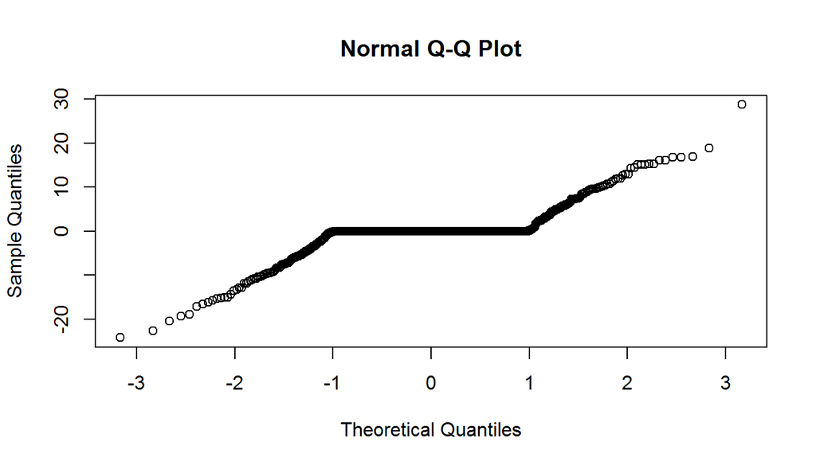

```r
qqnorm(movies_model$residuals)
```

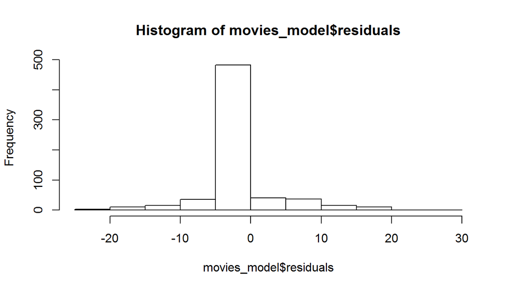

```r
hist(movies_model$residuals)
```

There a high concentration around zero, but this is not a nearly normal distribution.

###### Constant Variability of Residuals

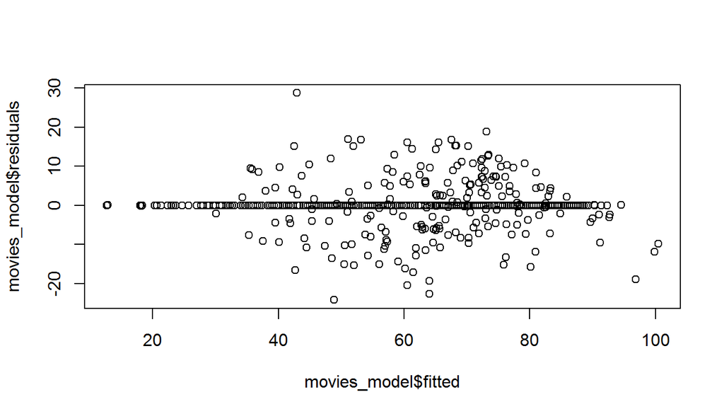

```r
plot(movies_model$residuals ~ movies_model$fitted)
```

### Model Summary

```r
s <- summary(movies_model)
s
```

```
##
## Call:
## lm(formula = overall_score ~ title_type + mpaa_rating + best_pic_nom +
##     top200_box + director + has_oscar + time_releases, data = movies)
##
## Residuals:
##    Min     1Q Median     3Q    Max
## -24.21   0.00   0.00   0.00  28.75
##
## Coefficients: (1 not defined because of singularities)
##                                     Estimate Std. Error t value Pr(>|t|)
## (Intercept)                          38.2542    18.3963   2.079 0.039943
## title_typeFeature Film              -11.5024    12.5858  -0.914 0.362795
## title_typeTV Movie                  -72.5803    21.8879  -3.316 0.001244
## mpaa_ratingNC-17                     42.6812    18.5998   2.295 0.023683
## mpaa_ratingPG                       -13.2680    10.5951  -1.252 0.213174
## mpaa_ratingPG-13                    -14.4233    10.5965  -1.361 0.176302
## mpaa_ratingR                         -8.5998    10.4995  -0.819 0.414556
## mpaa_ratingUnrated                   -0.3654    15.1798  -0.024 0.980839
## best_pic_nomyes                      21.5506     5.6547   3.811 0.000230
## top200_boxyes                         6.9664     6.1165   1.139 0.257238
## directorAbel Ferrara                 50.7701    15.4678   3.282 0.001387
## directorAdam McKay                   50.4854    15.4683   3.264 0.001473
## directorAdam Salky                   32.3285    15.4652   2.090 0.038929
## directorAdam Shankman                67.8495    15.8624   4.277 4.10e-05
## directorAdam Simon                    1.2116    15.4878   0.078 0.937789
## directorAdrian Grenier               50.9251    19.7292   2.581 0.011187
## directorAgnes Varda                  46.2584    19.7292   2.345 0.020872
## directorAgnieszka Holland            36.8603    13.6526   2.700 0.008054
## directorAlan Alda                    22.0917    13.1470   1.680 0.095777
## directorAlejandro Agresti            39.8548    16.1095   2.474 0.014918
## directorAlejandro Gonzalez Inarritu  57.0004    15.7523   3.619 0.000452
## directorAlejandro Jodorowsky         64.3285    15.4652   4.160 6.42e-05
## directorAlex Chandon                 12.4757    15.4641   0.807 0.421583
## directorAlex Gregory                 26.8480    15.4683   1.736 0.085473
## directorAlex Smith                   40.6618    15.4652   2.629 0.009805
## directorAlexandre Aja                21.3285    15.4652   1.379 0.170705
## directorAlice Wu                     65.5146    15.4683   4.235 4.81e-05
## directorAllan Arkush                 50.1266    16.0291   3.127 0.002268
## directorAlonso Mayo                  50.6136    19.0151   2.662 0.008960
```

[output cut: 1051 more lines]

```
## directorWilliam Shatner
## directorWim Wenders                 **
## directorWolfgang Reitherman
## directorWoody Allen                 ***
## directorYoshiaki Kawajiri           ***
## directorYurek Bogayevicz            .
## directorYves Simoneau
## has_oscarTRUE                       .
## time_releases                       **
## ---
## Signif. codes:  0 '***' 0.001 '**' 0.01 '*' 0.05 '.' 0.1 ' ' 1
##
## Residual standard error: 12.57 on 108 degrees of freedom
## Multiple R-squared:  0.9211, Adjusted R-squared:  0.5249
## F-statistic: 2.325 on 542 and 108 DF,  p-value: 1.647e-07
```

As the model p-value is 1.647e-07 we can assume that this is a good model.

## Part 5: Prediction

Predicting the 2016 movie [Ben-Hur (2016)](http://www.imdb.com/title/tt2638144/) with a confidence interval of 95%.

```r
new_movie <- data.frame(title_type = "Feature Film",
                        genre = "Drama",
                        mpaa_rating = "PG-13",
                        top200_box = "yes",
                        best_pic_nom = factor("no", levels = c("no", "yes"), nmax = 2),
                        director = "Timur Bekmambetov",
                        time_releases = 0,
                        has_oscar = factor(FALSE, levels = c(TRUE, FALSE), nmax = 2))

predicted_score <- predict (movies_model, new_movie, interval = "confidence", level = 0.95)
predicted_score %>%
  as.data.frame() %>%
  data.table::setnames(., c("Predicted Score", "Lower Bound", "Upper Bound")) %>%
  pander()
```

| Predicted Score | Lower Bound | Upper Bound |
| --- | --- | --- |
| 70.48 | 42.3 | 98.65 |

In this prediction we are extrapolating the model, because Ben Hur (2016) is beyond the range of years of the model.

Linear Regression is not a good modeling tool for extrapolation, so doing this is discouraged to do, due to the unreliable result of extrapolation.

## Part 6: Conclusion

The data does not provide convince evidence to reject the Null hypothesis in favor of Alternative hypothesis, so the studio could produce a sucessful film without a team made by Oscar winners.

We can predict a score for a movie outside the range of model, but with a wide variance (56.3458366 points), this is not recommended.

We can find a simple model with a good adjusted R^2 value.